# **Projeto - Introdução à Ciência de Dados**

Ano Letivo 2024/2025

**Grupo nº 7**

| Nome | N.º Mec. |
| --- | --- |
| Catarina Fernandes | 102703 |
| Fátima Rbaibi | 108858 |
| Isabela Alves | 108830 |

## **Introdução**

No âmbito da disciplina de Introdução à Ciência de Dados, o presente trabalho visa explorar dados de forma a extrair *insights* relevantes e identificar padrões significativos, aplicando técnicas de análise e visualização. Através de um conjunto de dados proveniente de publicações científicas, o estudo pretende evidenciar como o uso da Ciência de Dados pode contribuir para a compreensão de fenómenos específicos, neste caso a felicidade, utilizando ferramentas estatísticas e computacionais. Mais especificamente, este estudo bibliométrico engloba uma análise preliminar da evolução temporal do número de publicações, das áreas científicas predominantes, da coocorrência de palavras nos títulos e resumos, das citações de documentos, para além de também destacar os autores e as instituições mais influentes, as redes de colaboração científica, os documentos de referência e o acoplamento bibliográfico e os países que lideram esta pesquisa. No final, é feita uma reflexão no sentido de concluir como as técnicas de *Machine Learning* poderiam ser de útil aplicação no contexto da presente investigação.

**Metodologia**

**Identificação da questão de investigação e objetivos**

Com a intensificação das pressões sociais e do stress na sociedade atual, a felicidade e o bem-estar emocional têm se tornado tópicos de grande interesse em diversas áreas do conhecimento, incluindo psicologia, ciências sociais e saúde pública. Deste modo, tendo em conta a crescente relevância em entender os fatores que promovem a felicidade e, consequentemente, a qualidade de vida, no âmbito deste trabalho foi colocada a questão: **“Determinantes da felicidade: Quais os fatores que contribuem para o bem-estar emocional?”**. Sendo assim, o objetivo deste estudo é identificar e analisar esses fatores, através de uma revisão analítica da literatura científica.

**Seleção da fonte de dados**

Para esta investigação selecionou-se a base de dados *Scopus*, da *Elsevier*, como fonte de dados principal. A escolha da *Scopus* como fonte de dados para este estudo é justificada pela sua posição como uma das principais coleções de resumos e citações académicas do mundo. A *Scopus* oferece acesso a uma ampla gama de literatura académica em diversas disciplinas, permitindo uma exploração abrangente dos fatores que contribuem para o bem-estar emocional. Além disso, a cobertura superior da *Scopus* em mercados emergentes permite ter acesso a pesquisas críticas e de alta qualidade de países em desenvolvimento, muitas vezes ausentes em outras bases de dados. Por fim, com um processo de revisão independente, realizado por especialistas reconhecidos, a *Scopus* destaca-se como uma escolha ideal para análises rigorosas da literatura científica.

**Definição dos critérios de pesquisa**

O processo de pesquisa exigiu um exercício iterativo, com várias revisões e ajustes, de modo a possibilitar a definição cuidadosa do conjunto de critérios mais adequado e relevante para a presente investigação. No início deste processo, foram selecionados os termos de pesquisa **(“happiness” OR “emotional well-being”) AND “determinants”**, cuja combinação resultou num total de 1.364 publicações. Embora o conjunto de resultados tenha sido considerável, ficou evidente que poderiam estar a ser deixadas de parte publicações relacionadas ao tema, que fossem significativas e acrescentassem valor ao estudo.

Sendo assim, para ampliar o alcance da pesquisa e assegurar a inclusão de estudos importantes, optou-se por um refinamento da estratégia de busca. Assim, utilizou-se a seguinte combinação de termos: **(“happiness” OR “emotional well-being” OR “life satisfaction”) AND (“determinants” OR “predictors” OR “factors”)**. Essa abordagem resultou em 26.398 resultados, proporcionando uma gama mais abrangente de publicações sobre o assunto.

Adicionalmente, para garantir que as publicações selecionadas fossem as mais atuais e pertinentes, foram aplicadas restrições adicionais à pesquisa, nomeadamente a limitação a artigos publicados entre os anos de 2009 e 2024. Além disso, o foco foi direcionado para os artigos e para a área das Ciências Sociais, tendo os documentos sido também restringidos à língua inglesa, de modo a manter a relevância e a acessibilidade do material. Por fim, optou-se por selecionar apenas publicações em formato de *Open Acess* e que tivessem atingido o estágio de publicação final, garantindo que os resultados estivessem amplamente disponíveis e com níveis mínimos de rigor e qualidade. A aplicação destes filtros proporcionou um conjunto final de 2.165 publicações.

**Importação de bibliotecas**

```python
import pandas as pd
import matplotlib.pyplot as plt
import matplotlib.image as mpimg
import urllib.request
from PIL import Image
from google.colab import data_table
import gdown
import os
import textwrap
import seaborn as sns
from IPython.display import IFrame
```

## **Análise Bibliométrica**

**Importação do conjunto de dados**

```python
# Dicionário com os ids dos arquivos para download
file_ids = {
    'scopus': '163zSlCPccFZ-EiIF5RxvdaVo4C2jT868'
}

# Fazer o download dos ficheiros
for nome_ficheiro, file_id in file_ids.items():
    output = f'{nome_ficheiro}.csv'  # Nome do arquivo CSV que será salvo
    gdown.download(f'https://drive.google.com/uc?id={file_id}', output, quiet=False)

    # Verificar se o ficheiro foi baixado com sucesso
    if os.path.exists(output):
        print(f'{output} foi baixado com sucesso!')
    else:
        print(f'{output} falhou o download!')

# Carregar o CSV num DataFrame (caso o ficheiro exista)
if os.path.exists('scopus.csv'):
    DataFrame = pd.read_csv('scopus.csv')

else:
    print("Ficheiro CSV não encontrado.")
```

```
Downloading...
From: https://drive.google.com/uc?id=163zSlCPccFZ-EiIF5RxvdaVo4C2jT868
To: /content/scopus.csv
```

```
scopus.csv foi baixado com sucesso!
```

```python
DataFrame.head()
```

|  | Authors | Author full names | Author(s) ID | Title | Year | Source title | Volume | Issue | Art. No. | Page start | ... | ISBN | CODEN | PubMed ID | Language of Original Document | Abbreviated Source Title | Document Type | Publication Stage | Open Access | Source | EID |
| --- | --- | --- | --- | --- | --- | --- | --- | --- | --- | --- | --- | --- | --- | --- | --- | --- | --- | --- | --- | --- | --- |
| 0 | Li H.; Hiwatari M. | Li, Honghui (58933954800); Hiwatari, Masato (5... | 58933954800; 57192068316 | Unveiling the direct and indirect effects of s... | 2024 | Humanities and Social Sciences Communications | 11 | 1 | 391 | NaN | ... | NaN | NaN | NaN | English | Hum. Soc. Sci. Comm | Article | Final | All Open Access; Gold Open Access | Scopus | 2-s2.0-85187524361 |
| 1 | Jantsch A.; Le Blanc J.; Schmidt T. | Jantsch, Antje (56763704300); Le Blanc, Julia ... | 56763704300; 57190162380; 57203906256 | Beyond Income: Exploring the Role of Household... | 2024 | Journal of Happiness Studies | 25 | 7 | 101 | NaN | ... | NaN | NaN | NaN | English | J. Happiness Stud. | Article | Final | All Open Access; Hybrid Gold Open Access | Scopus | 2-s2.0-85204929186 |
| 2 | Fernandes M.I.; Sousa C.; Conde A.R.; Silva F.... | Fernandes, Maria Inês (58750137800); Sousa, Cl... | 58750137800; 7006164643; 26535716300; 58750364... | Exploring the Relationship between Capacity to... | 2024 | Sexuality and Culture | 28 | 4 | NaN | 1424 | ... | NaN | NaN | NaN | English | Sex. Cult. | Article | Final | All Open Access; Hybrid Gold Open Access | Scopus | 2-s2.0-85178932663 |
| 3 | Lund L.; Andersen S.; Ritz C.; Bast L.S. | Lund, Lisbeth (57202196075); Andersen, Susan (... | 57202196075; 7201431034; 56441102400; 56174153200 | Predicting longitudinal changes in patterns of... | 2024 | Social Science and Medicine | 352 | NaN | 117029 | NaN | ... | NaN | SSMDE | 38843676.0 | English | Soc. Sci. Med. | Article | Final | All Open Access; Hybrid Gold Open Access | Scopus | 2-s2.0-85195103333 |
| 4 | Li Y.; Wang Z.; Zhu Y. | Li, Yapeng (57818701200); Wang, Zihao (5932988... | 57818701200; 59329888800; 59330478800 | How Does Government Intervention Affect Commun... | 2024 | Sustainability (Switzerland) | 16 | 17 | 7326 | NaN | ... | NaN | NaN | NaN | English | Sustainability | Article | Final | All Open Access; Gold Open Access | Scopus | 2-s2.0-85204117306 |

5 rows × 46 columns

```python
DataFrame.shape
```

```
(2165, 46)
```

```python
DataFrame.columns
```

```
Index(['Authors', 'Author full names', 'Author(s) ID', 'Title', 'Year',
       'Source title', 'Volume', 'Issue', 'Art. No.', 'Page start', 'Page end',
       'Page count', 'Cited by', 'DOI', 'Link', 'Affiliations',
       'Authors with affiliations', 'Abstract', 'Author Keywords',
       'Index Keywords', 'Molecular Sequence Numbers', 'Chemicals/CAS',
       'Tradenames', 'Manufacturers', 'Funding Details', 'Funding Texts',
       'References', 'Correspondence Address', 'Editors', 'Publisher',
       'Sponsors', 'Conference name', 'Conference date', 'Conference location',
       'Conference code', 'ISSN', 'ISBN', 'CODEN', 'PubMed ID',
       'Language of Original Document', 'Abbreviated Source Title',
       'Document Type', 'Publication Stage', 'Open Access', 'Source', 'EID'],
      dtype='object')
```

**Importação de dados adicionais**

```python
# Dicionário com os nomes dos arquivos e seus IDs no Google Drive
file_ids = {
    'organizations': '1wleNfowjRFvXK9EdpJI_0DuhqAhgZb4D',
    'authors': '1wCqAhsk9MmDfanzBbd_B_vIhcLDbdxro',
    'countries': '1dF2KVk1TEBeH3HA4lpTF7Ccg92WLD8Gn',
    'bibliographic_coupling': '1TMY3uI-lY0HUFRPsfwIl7wQdezM8iSe5',
    'sources': '1jYczBqZfiljvoJfSygyN0AZNV5EmQSSI'

}

# Fazer o download de cada arquivo no dicionário
dataframes = {}  # Dicionário para armazenar cada DataFrame com o nome do arquivo

for nome_ficheiro, file_id in file_ids.items():
    # Definindo o nome do arquivo com a extensão .csv
    output = f'{nome_ficheiro}.csv'

    # Download do arquivo do Google Drive
    gdown.download(f'https://drive.google.com/uc?id={file_id}', output, quiet=False)

    # Verificar se o arquivo foi baixado com sucesso e carregá-lo no DataFrame
    if os.path.exists(output):
        print(f'{output} foi baixado com sucesso!')

        # Carregar o CSV em um DataFrame e armazenar no dicionário
        df = pd.read_csv(output)
        dataframes[nome_ficheiro] = df
        print(f"{nome_ficheiro} carregado:")
        print(df.head())
    else:
        print(f'Falha ao baixar {output}.')
```

```
Downloading...
From: https://drive.google.com/uc?id=1wleNfowjRFvXK9EdpJI_0DuhqAhgZb4D
To: /content/organizations.csv
```

```
organizations.csv foi baixado com sucesso!
organizations carregado:
       id                                              label       x       y  \
0   562.0   columbia university, new york, ny, united states -0.3549 -0.7814
1  1748.0  department of psychology, michigan state unive... -0.6621  0.1073
2  4178.0  school of hospitality and tourism management, ...  0.2088  0.8242
3  3504.0  max planck institute for human development, be... -0.6472 -0.4600
4  2808.0      german centre of gerontology, berlin, germany -0.6467 -0.4600

   cluster  weight<Links>  weight<Total link strength>  weight<Documents>  \
0      5.0            0.0                          0.0                3.0
1     11.0            0.0                          0.0                4.0
2     17.0            0.0                          0.0                3.0
3      3.0            1.0                          1.0                7.0
4      3.0            1.0                          1.0                3.0

   weight<Citations>  weight<Norm. citations>  score<Avg. pub. year>  \
0              255.0                   3.6811              2015.3333
1              183.0                   3.7778              2014.2500
2              136.0                   6.6027              2019.0000
3              132.0                   6.5040              2017.7143
4              112.0                   4.2812              2016.6667

   score<Avg. citations>  score<Avg. norm. citations>  Unnamed: 13
0                85.0000                       1.2270          NaN
1                45.7500                       0.9444          NaN
2                45.3333                       2.2009          NaN
3                18.8571                       0.9291          NaN
4                37.3333                       1.4271          NaN
```

```
Downloading...
From: https://drive.google.com/uc?id=1wCqAhsk9MmDfanzBbd_B_vIhcLDbdxro
To: /content/authors.csv
```

```
authors.csv foi baixado com sucesso!
authors carregado:
     id              label       x       y  cluster  weight<Links>  \
0   448   ballas, dimitris  0.2893 -0.1434        4              0
1  2059    gerstorf, denis -0.2080  0.4297        1              3
2  2686  infurna, frank j. -0.3629  0.6024        1              3
3  3071      kim, hak-seon  0.6943 -0.5825        5              0
4  3206    kourtit, karima  0.5861  0.5318        3              1

   weight<Total link strength>  weight<Documents>  weight<Citations>  \
0                            0                  5                319
1                           19                 10                255
2                           11                  6                235
3                            0                  5                146
4                            6                  6                 46

   weight<Norm. citations>  score<Avg. pub. year>  score<Avg. citations>  \
0                  10.2055              2020.2000                63.8000
1                   8.4140              2016.3000                25.5000
2                   8.2939              2016.5000                39.1667
3                   9.1819              2020.8000                29.2000
4                   5.4098              2022.3333                 7.6667

   score<Avg. norm. citations>
0                       2.0411
1                       0.8414
2                       1.3823
3                       1.8364
4                       0.9016
```

```
Downloading...
From: https://drive.google.com/uc?id=1dF2KVk1TEBeH3HA4lpTF7Ccg92WLD8Gn
To: /content/countries.csv
```

```
countries.csv foi baixado com sucesso!
countries carregado:
            label  cluster  weight<Links>  weight<Total link strength>  \
0   united states        5             51                          277
1  united kingdom        3             55                          253
2           china        3             33                          117
3         germany        4             42                          155
4           spain        6             44                          124

   weight<Documents>  weight<Citations>  weight<Norm. citations>  \
0                449              14123                 518.9281
1                258               8368                 341.3888
2                164               2503                 176.7855
3                136               3777                 154.5577
4                122               1701                 143.1994

   score<Avg. pub. year>  score<Avg. citations>  score<Avg. norm. citations>
0              2018.6325                31.4543                       1.1557
1              2019.2674                32.4341                       1.3232
2              2021.1159                15.2622                       1.0780
3              2019.6912                27.7721                       1.1365
4              2020.9590                13.9426                       1.1738
```

```
Downloading...
From: https://drive.google.com/uc?id=1TMY3uI-lY0HUFRPsfwIl7wQdezM8iSe5
To: /content/bibliographic_coupling.csv
```

```
bibliographic_coupling.csv foi baixado com sucesso!
bibliographic_coupling carregado:
     id             label                                        description  \
0  1956  mackerron (2013)  <table><tr><td>Authors:</td><td>mackerron, geo...
1  2032      aknin (2013)  <table><tr><td>Authors:</td><td>aknin, lara b....
2  1963      cheng (2014)  <table><tr><td>Authors:</td><td>cheng, cecilia...
3  1951  siedlecki (2014)  <table><tr><td>Authors:</td><td>siedlecki, kar...
4  2144    hirschi (2009)  <table><tr><td>Authors:</td><td>hirschi, andre...

                                               url  cluster  weight<Links>  \
0  https://doi.org/10.1016/j.gloenvcha.2013.03.010        2            122
1                 https://doi.org/10.1037/a0031578        3            655
2          https://doi.org/10.1089/cyber.2014.0317        3            107
3        https://doi.org/10.1007/s11205-013-0361-4        1            520
4        https://doi.org/10.1016/j.jvb.2009.01.002        1            431

   weight<Total link strength>  weight<Citations>  weight<Norm. citations>  \
0                          167                629                   6.5885
1                         1011                498                   5.2163
2                          108                483                   6.9568
3                          703                435                   6.2654
4                          504                320                   2.4166

   score<Pub. year>  score<Citations>  score<Norm. citations>
0              2013               629                  6.5885
1              2013               498                  5.2163
2              2014               483                  6.9568
3              2014               435                  6.2654
4              2009               320                  2.4166
```

```
Downloading...
From: https://drive.google.com/uc?id=1jYczBqZfiljvoJfSygyN0AZNV5EmQSSI
To: /content/sources.csv
```

```
sources.csv foi baixado com sucesso!
sources carregado:
  id;label;x;y;cluster;weight<Links>;weight<Total link strength>;weight<Documents>;weight<Citations>;weight<Norm. citations>;score<Avg. pub. year>;score<Avg. citations>;score<Avg. norm. citations>
0  11;ageing and society;-0.3729;-0.0862;1;3;3;10...
1  12;ageing international;-0.3701;-0.0893;1;1;1;...
2  13;aids care - psychological and socio-medical...
3  23;american journal of health promotion;-0.406...
4  24;american journal of men's health;-0.4687;-0...
```

```python
dataframes['countries'].head()
```

|  | label | cluster | weight<Links> | weight<Total link strength> | weight<Documents> | weight<Citations> | weight<Norm. citations> | score<Avg. pub. year> | score<Avg. citations> | score<Avg. norm. citations> |
| --- | --- | --- | --- | --- | --- | --- | --- | --- | --- | --- |
| 0 | united states | 5 | 51 | 277 | 449 | 14123 | 518.9281 | 2018.6325 | 31.4543 | 1.1557 |
| 1 | united kingdom | 3 | 55 | 253 | 258 | 8368 | 341.3888 | 2019.2674 | 32.4341 | 1.3232 |
| 2 | china | 3 | 33 | 117 | 164 | 2503 | 176.7855 | 2021.1159 | 15.2622 | 1.0780 |
| 3 | germany | 4 | 42 | 155 | 136 | 3777 | 154.5577 | 2019.6912 | 27.7721 | 1.1365 |
| 4 | spain | 6 | 44 | 124 | 122 | 1701 | 143.1994 | 2020.9590 | 13.9426 | 1.1738 |

```python
dataframes['countries'].shape
```

```
(67, 10)
```

```python
dataframes['authors'].head()
```

|  | id | label | x | y | cluster | weight<Links> | weight<Total link strength> | weight<Documents> | weight<Citations> | weight<Norm. citations> | score<Avg. pub. year> | score<Avg. citations> | score<Avg. norm. citations> |
| --- | --- | --- | --- | --- | --- | --- | --- | --- | --- | --- | --- | --- | --- |
| 0 | 448 | ballas, dimitris | 0.2893 | -0.1434 | 4 | 0 | 0 | 5 | 319 | 10.2055 | 2020.2000 | 63.8000 | 2.0411 |
| 1 | 2059 | gerstorf, denis | -0.2080 | 0.4297 | 1 | 3 | 19 | 10 | 255 | 8.4140 | 2016.3000 | 25.5000 | 0.8414 |
| 2 | 2686 | infurna, frank j. | -0.3629 | 0.6024 | 1 | 3 | 11 | 6 | 235 | 8.2939 | 2016.5000 | 39.1667 | 1.3823 |
| 3 | 3071 | kim, hak-seon | 0.6943 | -0.5825 | 5 | 0 | 0 | 5 | 146 | 9.1819 | 2020.8000 | 29.2000 | 1.8364 |
| 4 | 3206 | kourtit, karima | 0.5861 | 0.5318 | 3 | 1 | 6 | 6 | 46 | 5.4098 | 2022.3333 | 7.6667 | 0.9016 |

```python
dataframes['authors'].shape
```

```
(14, 13)
```

```python
dataframes['organizations'].head()
```

|  | id | label | x | y | cluster | weight<Links> | weight<Total link strength> | weight<Documents> | weight<Citations> | weight<Norm. citations> | score<Avg. pub. year> | score<Avg. citations> | score<Avg. norm. citations> | Unnamed: 13 |
| --- | --- | --- | --- | --- | --- | --- | --- | --- | --- | --- | --- | --- | --- | --- |
| 0 | 562.0 | columbia university, new york, ny, united states | -0.3549 | -0.7814 | 5.0 | 0.0 | 0.0 | 3.0 | 255.0 | 3.6811 | 2015.3333 | 85.0000 | 1.2270 | NaN |
| 1 | 1748.0 | department of psychology, michigan state unive... | -0.6621 | 0.1073 | 11.0 | 0.0 | 0.0 | 4.0 | 183.0 | 3.7778 | 2014.2500 | 45.7500 | 0.9444 | NaN |
| 2 | 4178.0 | school of hospitality and tourism management, ... | 0.2088 | 0.8242 | 17.0 | 0.0 | 0.0 | 3.0 | 136.0 | 6.6027 | 2019.0000 | 45.3333 | 2.2009 | NaN |
| 3 | 3504.0 | max planck institute for human development, be... | -0.6472 | -0.4600 | 3.0 | 1.0 | 1.0 | 7.0 | 132.0 | 6.5040 | 2017.7143 | 18.8571 | 0.9291 | NaN |
| 4 | 2808.0 | german centre of gerontology, berlin, germany | -0.6467 | -0.4600 | 3.0 | 1.0 | 1.0 | 3.0 | 112.0 | 4.2812 | 2016.6667 | 37.3333 | 1.4271 | NaN |

```python
dataframes['organizations'].shape
```

```
(24, 14)
```

```python
dataframes['bibliographic_coupling'].head()
```

|  | id | label | description | url | cluster | weight<Links> | weight<Total link strength> | weight<Citations> | weight<Norm. citations> | score<Pub. year> | score<Citations> | score<Norm. citations> |
| --- | --- | --- | --- | --- | --- | --- | --- | --- | --- | --- | --- | --- |
| 0 | 1956 | mackerron (2013) | <table><tr><td>Authors:</td><td>mackerron, geo... | https://doi.org/10.1016/j.gloenvcha.2013.03.010 | 2 | 122 | 167 | 629 | 6.5885 | 2013 | 629 | 6.5885 |
| 1 | 2032 | aknin (2013) | <table><tr><td>Authors:</td><td>aknin, lara b.... | https://doi.org/10.1037/a0031578 | 3 | 655 | 1011 | 498 | 5.2163 | 2013 | 498 | 5.2163 |
| 2 | 1963 | cheng (2014) | <table><tr><td>Authors:</td><td>cheng, cecilia... | https://doi.org/10.1089/cyber.2014.0317 | 3 | 107 | 108 | 483 | 6.9568 | 2014 | 483 | 6.9568 |
| 3 | 1951 | siedlecki (2014) | <table><tr><td>Authors:</td><td>siedlecki, kar... | https://doi.org/10.1007/s11205-013-0361-4 | 1 | 520 | 703 | 435 | 6.2654 | 2014 | 435 | 6.2654 |
| 4 | 2144 | hirschi (2009) | <table><tr><td>Authors:</td><td>hirschi, andre... | https://doi.org/10.1016/j.jvb.2009.01.002 | 1 | 431 | 504 | 320 | 2.4166 | 2009 | 320 | 2.4166 |

```python
dataframes['bibliographic_coupling'].shape
```

```
(20, 12)
```

```python
dataframes['sources'] = pd.read_csv('sources.csv', delimiter=';')
```

```python
dataframes['sources'].head()
```

|  | id | label | x | y | cluster | weight<Links> | weight<Total link strength> | weight<Documents> | weight<Citations> | weight<Norm. citations> | score<Avg. pub. year> | score<Avg. citations> | score<Avg. norm. citations> |
| --- | --- | --- | --- | --- | --- | --- | --- | --- | --- | --- | --- | --- | --- |
| 0 | 11 | ageing and society | -0.3729 | -0.0862 | 1 | 3 | 3 | 10 | 158 | 9.3971 | 2020.1000 | 15.8000 | 0.9397 |
| 1 | 12 | ageing international | -0.3701 | -0.0893 | 1 | 1 | 1 | 5 | 34 | 4.9434 | 2021.6000 | 6.8000 | 0.9887 |
| 2 | 13 | aids care - psychological and socio-medical as... | 0.5540 | -1.2342 | 13 | 0 | 0 | 5 | 98 | 2.8365 | 2016.6000 | 19.6000 | 0.5673 |
| 3 | 23 | american journal of health promotion | -0.4068 | 0.4366 | 10 | 1 | 1 | 7 | 64 | 4.8999 | 2020.8571 | 9.1429 | 0.7000 |
| 4 | 24 | american journal of men's health | -0.4687 | -0.0290 | 9 | 2 | 2 | 6 | 75 | 3.1947 | 2019.3333 | 12.5000 | 0.5324 |

```python
dataframes['sources'].shape
```

```
(79, 13)
```

## **1. Quando?**

**Análise da evolução temporal do número de publicações**

- Numa fase inicial, após o refinamento da pesquisa na *Scopus*, procedeu-se a uma análise da evolução temporal do número de publicações.

```python
# Agrupar por ano e contar o número de publicações

publicacoes_por_ano = DataFrame.groupby('Year').size()

publicacoes_por_ano
```

| Year | 0 |
| --- | --- |
| 2009 | 12 |
| 2010 | 30 |
| 2011 | 44 |
| 2012 | 39 |
| 2013 | 49 |
| 2014 | 49 |
| 2015 | 62 |
| 2016 | 81 |
| 2017 | 94 |
| 2018 | 135 |
| 2019 | 169 |
| 2020 | 192 |
| 2021 | 258 |
| 2022 | 334 |
| 2023 | 340 |
| 2024 | 277 |

**dtype:** int64

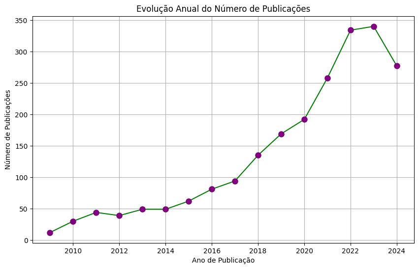

```python
plt.figure(figsize=(10, 6))
plt.plot(publicacoes_por_ano.index, publicacoes_por_ano.values, marker='o', linestyle='-', color='g', markerfacecolor='purple',  markeredgecolor='purple', markeredgewidth=3)
plt.xlabel('Ano de Publicação')
plt.ylabel('Número de Publicações')
plt.title('Evolução Anual do Número de Publicações')
plt.grid(True)
plt.show()
```

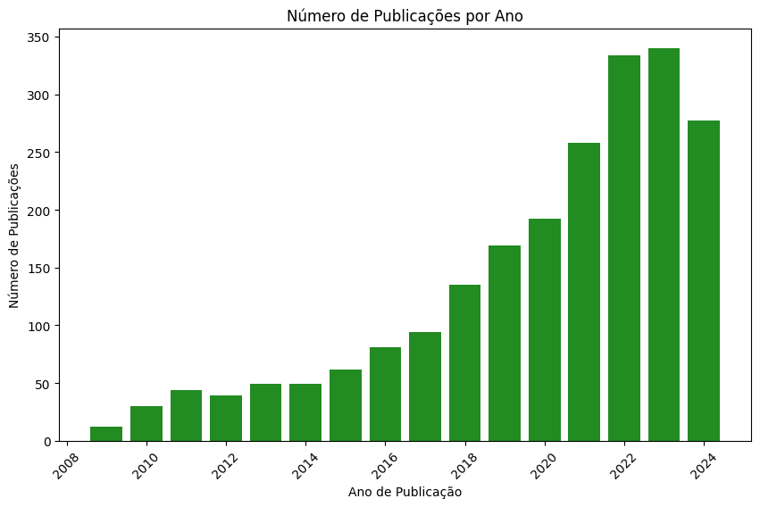

```python
plt.figure(figsize=(10, 6))
plt.bar(publicacoes_por_ano.index, publicacoes_por_ano.values, color='forestgreen')
plt.xlabel('Ano de Publicação')
plt.ylabel('Número de Publicações')
plt.title('Número de Publicações por Ano')
plt.xticks(rotation=45)
plt.show()
```

Deste modo, verifica-se um aumento ligeiro e gradual do número anual de publicações entre os anos 2009 e 2017, sendo que após este período o crescimento mostra-se bastante mais acentuado. Tal poderá ser reflexo de uma relevância crescente deste tema na sociedade atual, advindo da conscientização global sobre a importância do bem-estar para a saúde pública e a produtividade. Efetivamente, o tema da saúde mental está na ordem do dia e, aliado à procura incessante por qualidade de vida, impulsionou o interesse neste tema. Por fim, a partir de 2020, a pandemia de COVID-19 trouxe ainda mais atenção ao tema, à medida que as implicações do isolamento social e da saúde mental foram amplamente discutidas, incentivando mais estudos e publicações académicas.

## **2. O quê?**

**Áreas Científicas**

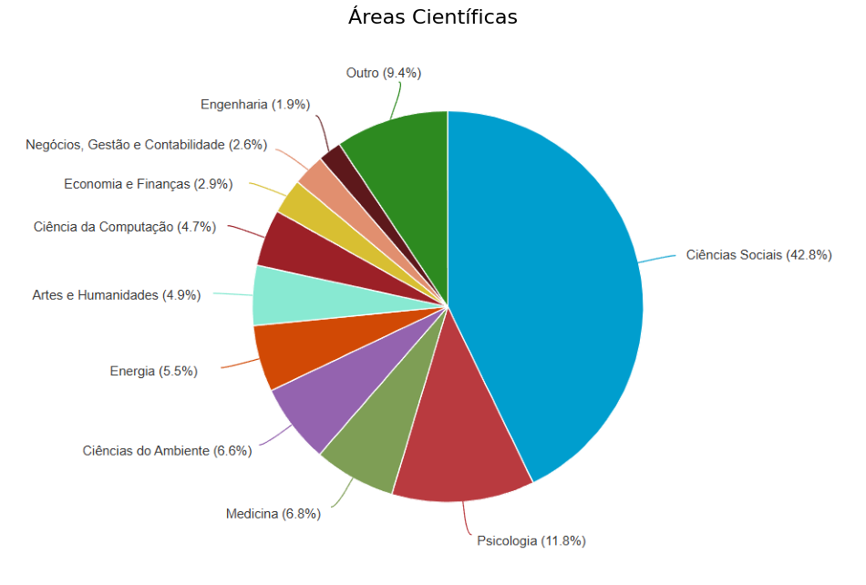

```python
# URL da imagem no Google Drive

url = 'https://drive.google.com/uc?id=1y7RewHVFoSItnBZy9U89R6JAoGGNXszP'  # Substitua pelo link formatado

# Baixar e carregar a imagem
with urllib.request.urlopen(url) as response:
    img = Image.open(response)

# Criar a figura e os eixos
fig, ax = plt.subplots(figsize=(12, 8))  # Definindo o tamanho da figura

# Adicionar um título à imagem
ax.set_title('Áreas Científicas', fontsize = 16, fontweight = 'light', ha = 'center', color = 'Black')

# Exibir a imagem
ax.imshow(img)
ax.axis('off')  #Ocultar eixos

# Mostrar a figura
plt.show()  # Substitua pelo link formatado
```

As Ciências Sociais predominam na publicação de artigos sobre o presente tema, representando uma parte significativa dos 26.398 documentos encontrados, juntamente com Psicologia e Medicina. As Ciências Sociais destacam-se por explorar como é que fatores sociais e económicos, como o rendimento e o contexto comunitário, influenciam o bem-estar. Esta predominância reflete a relevância das Ciências Sociais na compreensão da felicidade, complementada por abordagens multidisciplinares de áreas como Psicologia, Medicina, Economia e Artes, que enriquecem o estudo deste tema abrangente.

**Cocorrência de termos**

```python
# URL do VOSviewer
url = "https://tinyurl.com/22dwkz4j"

from IPython.display import Markdown
display(Markdown("## Mapa de Coocorrência de Termos"))

# Criar o IFrame
iframe_autKeywords = IFrame(src=url, width="100%", height="600px", style="border: 1px solid #ddd; max-width: 1000px; min-height: 500px")

# Exibir o IFrame
display(iframe_autKeywords)
```

Mapa de Coocorrência de Termos

[interactive chart not shown]

O mapa apresenta os termos em inglês mais frequentes nos 2165 documentos analisados, destacando relações e agrupamentos temáticos, tendo sido definido um mínimo de 55 ocorrências para facilitar insights úteis. Nós maiores representam palavras mais frequentes, enquanto a proximidade e conexões entre os nós indicam a força das relações entre os termos.

Foram identificados quatro clusters: o **verde**, focado em fatores psicológicos e educação (*stress*, *resilience*, *depression*); o **amarelo**, com fatores demográficos e saúde mental (*adolescent*, *self esteem*, *depressive symptom*); e os **azul e vermelho**, centrados em fatores socioeconómicos, como *income*, *social support* e *job satisfaction*.

A grande diversidade de domínios de exploração deste tema era expectável já que se trata de uma questão extremamente ampla que envolve uma variedade de fatores inter-relacionados. A felicidade é influenciada por aspectos económicos, sociais, psicológicos, culturais, entre outros, o que torna a sua análise multidisciplinar e complexa.

**Palavras-chave mais frequentes**

```python
missing_values_count = DataFrame['Author Keywords'].isnull().sum()
print(f"Número de valores ausentes em 'Author Keywords': {missing_values_count}")
```

```
Número de valores ausentes em 'Author Keywords': 124
```

```
Top 10 Author Keywords:
Author Keywords
Life satisfaction        278
Happiness                179
life satisfaction        139
Subjective well-being    134
Well-being               105
happiness                 80
well-being                70
COVID-19                  69
Mental health             60
Quality of life           53
Name: count, dtype: int64
```

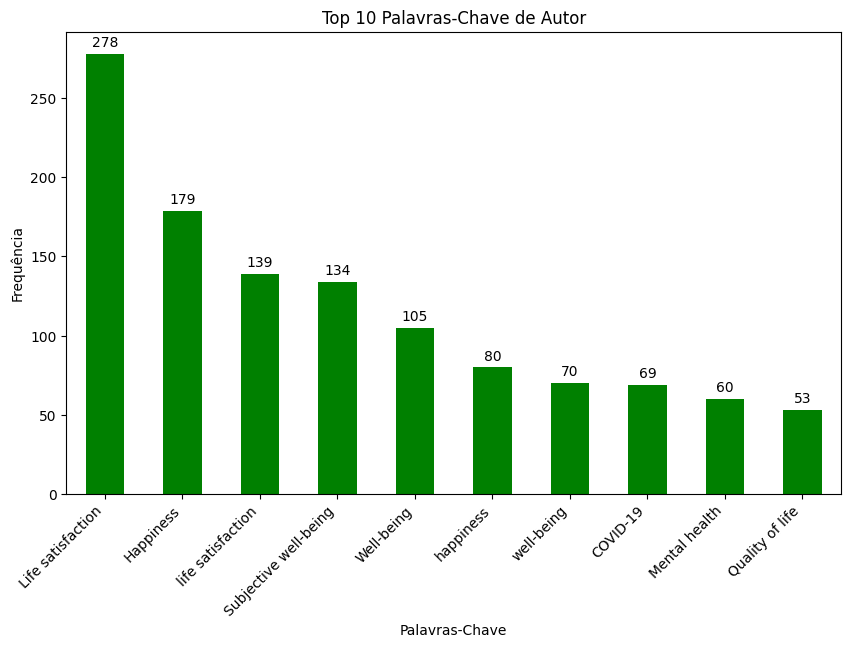

```python
# Fazer uma cópia da coluna 'Author Keywords' para preservar o DataFrame original
author_keywords = DataFrame['Author Keywords'].fillna('')  # Preenchendo valores ausentes na cópia

# Excluir entradas vazias e espaços em branco
author_keywords_cleaned = author_keywords[author_keywords.str.strip() != '']

# Explodir a cópia limpa da coluna 'Author Keywords' para separar e contar as palavras-chave mais frequentes
all_keywords = author_keywords_cleaned.str.split('; ').explode().str.strip().value_counts().head(10)

# Exibir os 10 termos mais frequentes
print("Top 10 Author Keywords:")
print(all_keywords)

# Configurar o gráfico e criar o objeto 'ax'
fig, ax = plt.subplots(figsize=(10, 6))
all_keywords.plot(kind='bar', color='green', ax=ax, title='Top 10 Palavras-Chave de Autor')

# Adicionar rótulos no topo de cada barra
ax.bar_label(ax.containers[0], label_type='edge', padding=3)

# Configurar rótulos dos eixos e título
ax.set_xlabel("Palavras-Chave")
ax.set_ylabel("Frequência")
plt.xticks(rotation=45, ha="right")  # Ajustar rótulos para melhor leitura
plt.show()
```

**Análise de citações dos documentos**

**Tabela dos 50 documentos mais citados**

```python
# Ordenar os dados pelo número de citações em ordem decrescente
df_Top50 = DataFrame.sort_values(by = 'Cited by', ascending=False).head(50)

# Exibir os 50 documentos mais citados
#print(df_Top50[['Title', 'Cited by', 'Year', 'Authors']])
```

```python
# Exibir o DataFrame como uma tabela interativa
data_table.DataTable(df_Top50[['Title', 'Cited by', 'Year', 'Authors']], include_index=False)
```

|  | Title | Cited by | Year | Authors |
| --- | --- | --- | --- | --- |
| 1113 | Risk and Protective Factors for Prospective Ch... | 868 | 2021 | Magson N.R.; Freeman J.Y.A.; Rapee R.M.; Richa... |
| 1955 | Happiness is greater in natural environments | 629 | 2013 | MacKerron G.; Mourato S. |
| 2031 | Prosocial spending and well-being: Cross-cultu... | 498 | 2013 | Aknin L.B.; Dunn E.W.; Helliwell J.F.; Biswas-... |
| 1962 | Internet addiction prevalence and quality of (... | 483 | 2014 | Cheng C.; Li A.Y.-L. |
| 1950 | The Relationship Between Social Support and Su... | 435 | 2014 | Siedlecki K.L.; Salthouse T.A.; Oishi S.; Jesw... |
| 2121 | A Cultural Task Analysis of Implicit Independe... | 416 | 2009 | Kitayama S.; Park H.; Sevincer A.T.; Karasawa ... |
| 2115 | Longing to belong: Social inclusion and wellbe... | 341 | 2010 | Correa-Velez I.; Gifford S.M.; Barnett A.G. |
| 2143 | Career adaptability development in adolescence... | 320 | 2009 | Hirschi A. |
| 2064 | Happiness and Satisfaction with Work Commute | 317 | 2013 | Olsson L.E.; Gärling T.; Ettema D.; Friman M.;... |
| 2040 | Rising income and the subjective well-being of... | 278 | 2013 | Diener E.; Tay L.; Oishi S. |
| 2107 | Still happy after all these years: Research fr... | 270 | 2010 | George L.K. |
| 2104 | Life Satisfaction Across the Lifespan: Finding... | 267 | 2010 | Baird B.M.; Lucas R.E.; Donnellan M.B. |
| 1906 | Midlife as a pivotal period in the life course... | 267 | 2015 | Lachman M.E.; Teshale S.; Agrigoroaei S. |
| 2160 | Modeling developmental language difficulties f... | 256 | 2009 | Law J.; Rush R.; Schoon I.; Parsons S. |
| 2061 | What makes a 'happy city'? | 253 | 2013 | Ballas D. |
| 2046 | Coastal proximity, health and well-being: Resu... | 245 | 2013 | White M.P.; Alcock I.; Wheeler B.W.; Depledge ... |
| 1933 | Benefits of having friends in older ages: Diff... | 242 | 2014 | Huxhold O.; Miche M.; Schüz B. |
| 2085 | Co-occurrence of addictive behaviours: Persona... | 232 | 2012 | Walther B.; Morgenstern M.; Hanewinkel R. |
| 1196 | The Ups and Downs of Daily Life during COVID-1... | 222 | 2021 | Klaiber P.; Wen J.H.; Delongis A.; Sin N.L. |
| 1747 | Analysis of the use of social media in Higher ... | 205 | 2017 | Dumpit D.Z.; Fernandez C.J. |
| 2021 | Altruism, helping, and volunteering: Pathways ... | 205 | 2013 | Kahana E.; Bhatta T.; Lovegreen L.D.; Kahana B... |
| 2072 | The impact of Immigration and Customs Enforcem... | 200 | 2011 | Hacker K.; Chu J.; Leung C.; Marra R.; Pirie A... |
| 2037 | Relationships of personality, affect, emotiona... | 199 | 2012 | Saklofske D.H.; Austin E.J.; Mastoras S.M.; Be... |
| 1138 | Up and About: Older Adults' Well-being during ... | 193 | 2021 | Kivi M.; Hansson I.; Bjälkebring P. |
| 2111 | Avatar creation and video game enjoyment | 186 | 2010 | Trepte S.; Reinecke L. |
| 2113 | The neurobiological toll of child abuse and ne... | 186 | 2009 | Neigh G.N.; Gillespie C.F.; Nemeroff C.B. |
| 2099 | The Happiness of Cities; [Le bonheur des grand... | 185 | 2013 | Florida R.; Mellander C.; Rentfrow P.J. |
| 2153 | National well-being and international sports e... | 183 | 2010 | Kavetsos G.; Szymanski S. |
| 974 | The effects of social isolation on well-being ... | 183 | 2021 | Clair R.; Gordon M.; Kroon M.; Reilly C. |
| 1778 | Loneliness and cognitive function in older adu... | 181 | 2017 | Zhong B.-L.; Chen S.-L.; Tu X.; Conwell Y. |
| 1055 | The gender gap in adolescent mental health: A ... | 180 | 2021 | Campbell O.L.K.; Bann D.; Patalay P. |
| 1915 | Happiness: Before and After the Kids | 177 | 2014 | Myrskylä M.; Margolis R. |
| 1470 | Impacts of knowledge sharing: a review and dir... | 170 | 2019 | Ahmad F.; Karim M. |
| 2010 | Sports participation and happiness: Evidence f... | 168 | 2012 | Huang H.; Humphreys B.R. |
| 1914 | The Pursuit of Happiness in China: Individuali... | 167 | 2013 | Steele L.G.; Lynch S.M. |
| 1729 | The subjective wellbeing of migrants in Guangz... | 161 | 2017 | Liu Y.; Zhang F.; Wu F.; Liu Y.; Li Z. |
| 1961 | The potential of social enterprise to enhance ... | 160 | 2014 | Roy M.J.; Donaldson C.; Baker R.; Kerr S. |
| 2127 | Trajectories of Emotional Well-Being in Mother... | 160 | 2011 | Barker E.T.; Hartley S.L.; Seltzer M.M.; Floyd... |
| 2049 | Assessing sustainable behavior and its correla... | 154 | 2013 | Tapia-Fonllem C.; Corral-Verdugo V.; Fraijo-Si... |
| 2082 | Is Personality Fixed? Personality Changes as M... | 153 | 2013 | Boyce C.J.; Wood A.M.; Powdthavee N. |
| 2158 | A Global Perspective on Happiness and Fertility | 152 | 2011 | Margolis R.; Myrskylä M. |
| 1960 | Food, water, and scarcity: Toward a broader an... | 151 | 2014 | Wutich A.; Brewis A. |
| 2138 | An intersectional approach for understanding p... | 151 | 2010 | Seaton E.K.; Caldwell C.H.; Sellers R.M.; Jack... |
| 1765 | Age and Gender Differences in the Associations... | 147 | 2017 | Bluth K.; Campo R.A.; Futch W.S.; Gaylord S.A. |
| 2142 | Don't wanna go through that madness no more: Q... | 144 | 2009 | Laudet A.B.; Becker J.B.; White W.L. |
| 1954 | Accidental falls, health-related quality of li... | 144 | 2014 | Stenhagen M.; Ekström H.; Nordell E.; Elmståhl S. |
| 1776 | The Role of Perceived Stress and Self-Efficacy... | 143 | 2017 | Burger K.; Samuel R. |
| 1925 | Mindfulness and Self-Compassion: Exploring Pat... | 140 | 2014 | Bluth K.; Blanton P.W. |
| 1640 | Domains and predictors of first-year student s... | 138 | 2018 | van der Zanden P.J.A.C.; Denessen E.; Cillesse... |
| 1338 | What drives customer satisfaction, loyalty, an... | 135 | 2020 | Zhong Y.; Moon H.C. |

```python
# Contar o número de documentos por ano
publicacoes_por_ano = df_Top50.groupby('Year').size().reset_index(name='Número de Publicações')

publicacoes_por_ano['Percentagem'] = (publicacoes_por_ano['Número de Publicações'] / publicacoes_por_ano['Número de Publicações'].sum()) * 100

# Calcular a percentagem cumulativa
publicacoes_por_ano['Percentagem Cumulativa'] = publicacoes_por_ano['Percentagem'].cumsum()

# Exibir a tabela
print(publicacoes_por_ano)
```

```
    Year  Número de Publicações  Percentagem  Percentagem Cumulativa
0   2009                      5         10.0                    10.0
1   2010                      6         12.0                    22.0
2   2011                      3          6.0                    28.0
3   2012                      3          6.0                    34.0
4   2013                     11         22.0                    56.0
5   2014                      8         16.0                    72.0
6   2015                      1          2.0                    74.0
7   2017                      5         10.0                    84.0
8   2018                      1          2.0                    86.0
9   2019                      1          2.0                    88.0
10  2020                      1          2.0                    90.0
11  2021                      5         10.0                   100.0
```

A análise dos 50 documentos mais citados evidencia a relevância de estudos fundamentais sobre felicidade e bem-estar emocional. O documento mais citado, com 868 citações, foi publicado em 2021, enquanto que 72% dos documentos analisados são anteriores a 2015, refletindo o impacto duradouro de trabalhos pioneiros que estabeleceram conceitos e metodologias importantes.

A baixa presença de artigos publicados entre 2018 e 2021 entre os mais citados sugere que esses trabalhos ainda estão a acumular reconhecimento académico. Além disso, nenhum documento a partir de 2022 surge entre os mais citados, reforçando que a pesquisa recente ainda está em fase de consolidação.

O menor número de documentos citados desses anos pode refletir uma fase de transição, com novos temas ou abordagens a emergirem. Esta transição poderá estar ligada à emergência do *Big Data*, que permite análises mais detalhadas e dinâmicas, revelando interações complexas entre fatores que influenciam o bem-estar. Embora os estudos anteriores tenham estabelecido fundamentos importantes, o *Big Data* amplia as possibilidades analíticas, promovendo uma compreensão mais holística e inovadora do tema.

**Distribuição do número de citações por ano de publicação**

Tendo em conta os 50 documentos mais citados, nesta seção foi analisada a distribuição do número de citações por ano de publicação, com o objetivo de perceber o impacto e relevância do tema ao longo do tempo. Pode-se identificar o crescimento ou declínio do interesse na área ou o tempo necessário para que artigos atinjam um número elevado de citações. Além disso, a ausência de publicações recentes entre as mais citadas sugere a maturação das contribuições fundamentais, enquanto aumentos em certos anos podem indicar picos de interesse devido a eventos ou avanços específicos.

```
    Year  Cited by
0   2009      1322
1   2010      1398
2   2011       512
3   2012       599
4   2013      3084
5   2014      1932
6   2015       267
7   2017       837
8   2018       138
9   2019       170
10  2020       135
11  2021      1646
```

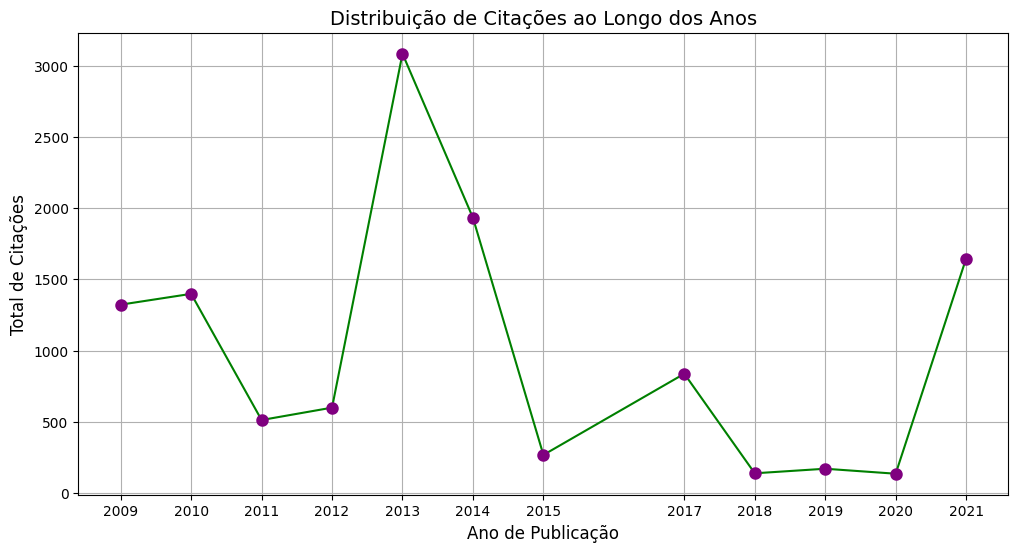

```python
# Agrupar os dados pelo ano de publicação e somar o número de citações
citações_por_ano = df_Top50.groupby('Year')['Cited by'].sum().reset_index()

# Visualizar o DataFrame resultante
print(citações_por_ano)

# Criar um gráfico para mostrar a quantidade de citações ao longo dos anos
plt.figure(figsize=(12, 6))
plt.plot(citações_por_ano['Year'], citações_por_ano['Cited by'],marker='o', linestyle='-', color='g', markerfacecolor='purple',  markeredgecolor='purple', markeredgewidth=3)
plt.title('Distribuição de Citações ao Longo dos Anos', fontsize=14)
plt.xlabel('Ano de Publicação', fontsize=12)
plt.ylabel('Total de Citações', fontsize=12)
plt.xticks(citações_por_ano['Year'])  # Marcar todos os anos no eixo x
plt.grid()
plt.show()
```

**Quais as revistas predominantes nas publicações?**

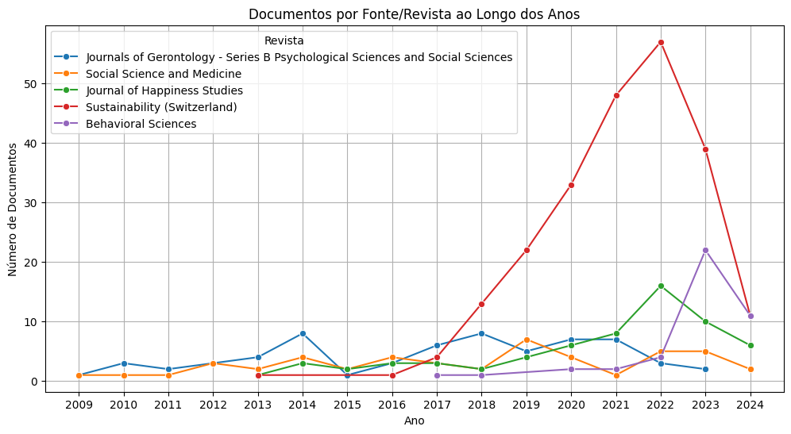

```python
total_por_revista = DataFrame['Source title'].value_counts().reset_index()
total_por_revista.columns = ['Source title', 'Total']

# Lista com as 5 revistas mais citadas no período em questão
top_5_revistas = total_por_revista.nlargest(5, 'Total')['Source title'].tolist()

# Seleciona as linhas do DataFrame original onde o 'Source title' está presente na lista top_5_revistas.
revistas_por_ano = DataFrame[DataFrame['Source title'].isin(top_5_revistas)].groupby(['Year', 'Source title'])['Source title'].count().reset_index(name='count')

# Agrupa as linhas selecionadas por 'Year' e 'Source title'.
# Em seguida, conta o número de ocorrências de 'Source title' em cada grupo.
# O resultado é convertido para um DataFrame com a coluna 'count' representando o número de ocorrências.
plt.figure(figsize=(12, 6))
sns.lineplot(x='Year', y='count', hue='Source title', data=revistas_por_ano, marker='o')
plt.title('Documentos por Fonte/Revista ao Longo dos Anos')
plt.xlabel('Ano')
plt.ylabel('Número de Documentos')
plt.xticks(revistas_por_ano['Year'].unique()) # Define os ticks do eixo x como os anos únicos
plt.legend(title='Revista')
plt.grid(True)
plt.show()
```

Entre 2009 e 2024, o número de publicações sobre felicidade revela tendências editoriais marcantes, com destaque para cinco revistas principais: *Journals of Gerontology - Series B*, *Social Science and Medicine*, *Journal of Happiness Studies*, *Sustainability (Switzerland)* e *Behavioral Sciences*. A análise evidencia um aumento significativo de publicações nos últimos anos, sobretudo em áreas ambientais e comportamentais. A revista *Sustainability (Switzerland)* destaca-se pelo crescimento acentuado a partir de 2016, atingindo um pico em 2022,com mais de 50 publicações, refletindo o interesse em abordagens interdisciplinares. No entanto, após 2022 observa-se uma queda nas publicações, sugerindo uma possível transição temática ou saturação.

Este panorama evidencia que algumas revistas específicas se consolidaram como as principais fontes de referência sobre o tema da felicidade ao longo dos anos, reforçando a sua significância e impacto contínuos na literatura académica. Todavia, esse cenário ainda abre espaço para que novas publicações ou fontes ganhem destaque, especialmente conforme surgem novas tendências e abordagens sobre o tema.

## **3. Quem?**

Com o intuito de identificar as principais instituições e autores na investigação sobre os determinantes da felicidade e do bem-estar emocional, foi realizada uma análise detalhada recorrendo a visualizações gráficas, tabelas e mapas de redes gerados no software VOSviewer. Para esta análise, desenvolveram-se gráficos de barras e três tipos de mapas de redes: um mapa de coautoria entre autores, um mapa de coautoria entre instituições e um mapa de acoplamento bibliográfico de documentos.

Esta abordagem permitiu identificar os investigadores mais ativos e influentes na área, mapear as principais redes de colaboração entre autores e instituições e destacar as publicações de maior impacto. Neste sentido, obteve-se uma visão clara das interligações e dinâmicas que caracterizam o campo de estudo, proporcionando uma base sólida para compreender as redes de cooperação e o papel das publicações que mais contribuem para o avanço do conhecimento na temática de felicidade e bem-estar emocional.

**Principais autores entre os documentos mais citados**

```
            Author  Count
0      Margolis R.      2
1         Bluth K.      2
2           Liu Y.      2
3      Myrskylä M.      2
4         Oishi S.      2
5      Magson N.R.      1
6       Chen S.-L.      1
7            Tu X.      1
8       Conwell Y.      1
9  Campbell O.L.K.      1
```

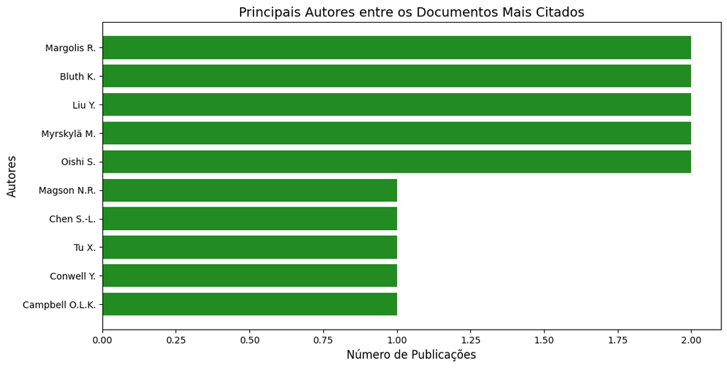

```python
# Separar os autores em linhas distintas
# Supondo que a coluna 'Authors' tenha autores separados por vírgula
autores_list = df_Top50['Authors'].str.split(';').explode().str.strip()

# Contar a frequência de cada autor
contagem_autores = autores_list.value_counts().reset_index()
contagem_autores.columns = ['Author', 'Count']

# Visualizar os principais autores
print(contagem_autores.head(10))  # Exibir os 10 autores mais frequentes

# Criar um gráfico para mostrar os autores mais recorrentes
plt.figure(figsize=(12, 6))
plt.barh(contagem_autores['Author'].head(10), contagem_autores['Count'].head(10), color='forestgreen')
plt.title('Principais Autores entre os Documentos Mais Citados', fontsize=14)
plt.xlabel('Número de Publicações', fontsize=12)
plt.ylabel('Autores', fontsize=12)
plt.gca().invert_yaxis()  # Inverter o eixo y para mostrar o autor mais frequente no topo
plt.show()
```

**Autores mais citados**

```
                      Author  Total Cited By
1362          Freeman J.Y.A.             868
3629         Richardson C.E.             868
3160                Oar E.L.             868
1258             Fardouly J.             868
3570              Rapee R.M.             868
6180             Magson N.R.             868
3177                Oishi S.             713
6170            MacKerron G.             629
2982              Mourato S.             629
3150               Nyende P.             498
1736          Helliwell J.F.             498
235        Ashton-James C.E.             498
1127               Dunn E.W.             498
2150               Kemeza I.             498
592                 Burns J.             498
339    Barrington-Leigh C.P.             498
436         Biswas-Diener R.             498
5104              Aknin L.B.             498
3136             Norton M.I.             498
2485              Li A.Y.-L.             483
```

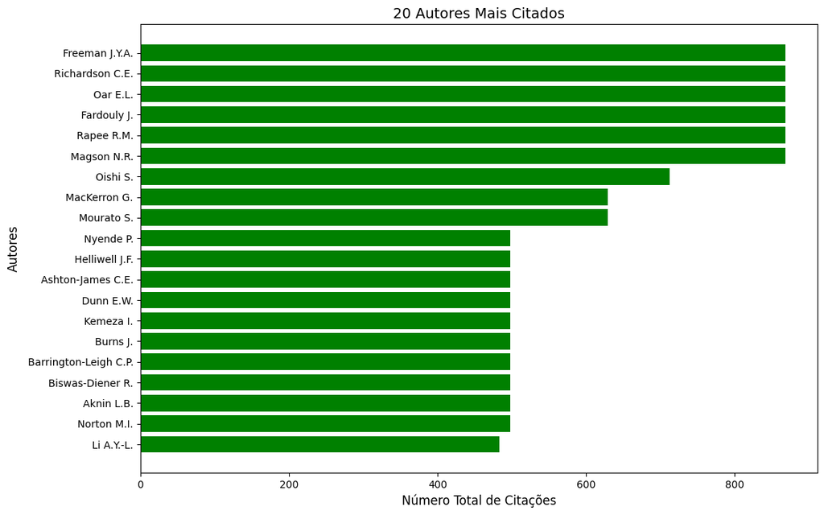

```python
# Separar os autores em linhas distintas
autores_list = DataFrame['Authors'].str.split(';').explode().str.strip()

# Adicionar a coluna de citações correspondente para cada autor
citações_por_autor = DataFrame[['Authors', 'Cited by']].copy()
citações_por_autor['Authors'] = citações_por_autor['Authors'].str.split(';')

# Explodir a lista de autores e duplicar as citações para cada autor
citações_por_autor = citações_por_autor.explode('Authors')

# Converter a coluna de citações para numérico (se não estiver)
citações_por_autor['Cited by'] = pd.to_numeric(citações_por_autor['Cited by'], errors='coerce')

# Agrupar por autor e somar as citações
contagem_autores = citações_por_autor.groupby('Authors')['Cited by'].sum().reset_index()
contagem_autores.columns = ['Author', 'Total Cited By']

# Ordenar os autores pelo total de citações em ordem decrescente
contagem_autores = contagem_autores.sort_values(by='Total Cited By', ascending=False)

# Filtrar os 20 autores mais citados
top_20_autores = contagem_autores.head(20)

# Visualizar os 20 principais autores
print(top_20_autores)

# Criar um gráfico para mostrar os 20 autores mais citados
plt.figure(figsize=(12, 8))
plt.barh(top_20_autores['Author'], top_20_autores['Total Cited By'], color='green')
plt.title('20 Autores Mais Citados', fontsize=14)
plt.xlabel('Número Total de Citações', fontsize=12)
plt.ylabel('Autores', fontsize=12)
plt.gca().invert_yaxis()  # Inverter o eixo y para mostrar o autor mais citado no topo
plt.show()
```

**Investigadores e instituições de destaque**

**Mapa de co-autoria**

```python
# URL do VOSviewer
url = "https://tinyurl.com/2xutklw8"

# Criar o elemento de título usando HTML
display(Markdown("## Mapa de Coautoria"))

# Criar o IFrame
iframe_autKeywords = IFrame(src=url, width="100%", height="600px", style="border: 1px solid #ddd; max-width: 1000px; min-height: 500px")

# Exibir o IFrame
display(iframe_autKeywords)
```

Mapa de Coautoria

[interactive chart not shown]

O **mapa de coautoria** revela uma rede estruturada em clusters que representam grupos de colaboração entre autores. No **cluster vermelho**, destacam-se "Ram, Nilam", "Gerstorf, Denis", "Wagner, Gert G." e "Infurna, Frank J.", formando um grupo fortemente interligado, com ligações consistentes e frequentes (força de ligação de 19, 15 e 11), sugerindo interesses de pesquisa comuns. O **cluster verde** inclui "Sutin, Angelina R.", "Terracciano, Antonio" e "Lucchetti, Martina", com colaboração significativa, mas menos intensa (força de ligação total de 10). No **cluster azul**, "Kourtit, Karima" e "Nijkamp, Peter" apresentam uma colaboração restrita e focada. Por outro lado, alguns autores aparecem de forma isolada, indicando participação mais independente.

**Publicações por autores**

```python
authors_df = dataframes['authors']

# Criar um novo DataFrame com as colunas desejadas
tabela_autores = authors_df[['label', 'cluster', 'weight<Documents>','weight<Links>',
       'weight<Total link strength>', 'weight<Citations>',
       'weight<Norm. citations>']].copy()

# Remove rows with all missing values
tabela_autores= tabela_autores.dropna(how='all').reset_index(drop=True)

# Renomear as colunas para português
tabela_autores.columns = ['Autores', 'Cluster', 'Número de Documentos','Força das Ligações',
                         'Força Total das Ligações','Número de Citações', 'Citações Normalizadas']

tabela_autores_ordenada = tabela_autores.sort_values(by=['Número de Documentos'], ascending=False)
tabela_autores_ordenada['Autores'] = tabela_autores_ordenada['Autores'].astype(str).apply(lambda x: x.title())

# Para exibir como tabela interativa no Colab:
data_table.DataTable(tabela_autores_ordenada)
```

|  | Autores | Cluster | Número de Documentos | Força das Ligações | Força Total das Ligações | Número de Citações | Citações Normalizadas |
| --- | --- | --- | --- | --- | --- | --- | --- |
| 1 | Gerstorf, Denis | 1 | 10 | 3 | 19 | 255 | 8.4140 |
| 9 | Prihadi, Kususanto Ditto | 8 | 10 | 0 | 0 | 58 | 4.1843 |
| 10 | Ram, Nilam | 1 | 10 | 3 | 19 | 303 | 9.8499 |
| 13 | Wagner, Gert G. | 1 | 7 | 3 | 15 | 122 | 4.2776 |
| 2 | Infurna, Frank J. | 1 | 6 | 3 | 11 | 235 | 8.2939 |
| 4 | Kourtit, Karima | 3 | 6 | 1 | 6 | 46 | 5.4098 |
| 5 | Lucas, Richard E. | 6 | 6 | 0 | 0 | 428 | 7.5775 |
| 7 | Marquez, Jose | 7 | 6 | 0 | 0 | 43 | 8.6305 |
| 8 | Nijkamp, Peter | 3 | 6 | 1 | 6 | 46 | 5.4098 |
| 0 | Ballas, Dimitris | 4 | 5 | 0 | 0 | 319 | 10.2055 |
| 3 | Kim, Hak-Seon | 5 | 5 | 0 | 0 | 146 | 9.1819 |
| 6 | Luchetti, Martina | 2 | 5 | 2 | 10 | 41 | 4.9539 |
| 11 | Sutin, Angelina R. | 2 | 5 | 2 | 10 | 41 | 4.9539 |
| 12 | Terracciano, Antonio | 2 | 5 | 2 | 10 | 41 | 4.9539 |

Com base na tabela Publicações por autores, destacam-se "Ram, Nilam", "Gerstorf, Denis" e "Prihadi, Kususanto Ditto", com 10 publicações cada, demonstrando forte presença na investigação sobre felicidade e bem-estar emocional, enquanto os demais autores têm contribuições relevantes, mas em menor volume. Quanto ao impacto científico, "Lucas, Richard E." lidera em citações totais (428), seguido por "Ballas, Dimitris" (319), cujo alto índice de citações normalizadas (10.2055, ajustadas para comparabilidade entre áreas e períodos de publicação) reforça a relevância e qualidade de seus estudos na área.

**Acoplamento bibliográfico**

```python
# URL do VOSviewer
url = "https://tinyurl.com/22r5du7o"

display(Markdown("## Mapa de Acoplamento Bibliográfico"))

# Criar o IFrame
iframe_autKeywords = IFrame(src=url, width="100%", height="600px", style="border: 1px solid #ddd; max-width: 1000px; min-height: 500px")

# Exibir o IFrame
display(iframe_autKeywords)
```

Mapa de Acoplamento Bibliográfico

[interactive chart not shown]

**DOCUMENTOS DE REFERÊNCIA E ACOPLAMENTO BIBLIOGRÁFICO**

Relativamente ao terceiro mapa, baseado no acoplamento bibliográfico de documentos, este mede a similaridade entre documentos com base nas suas referências bibliográficas. Esta análise é fundamental para identificar clusters de documentos que exploram tópicos semelhantes, uma vez que documentos com várias referências em comum tendem a abordar temas relacionados. O estudo de **Mackerron (2013)** é o mais destacado, surgindo como um documento central no cluster verde, indicando que serve como base teórica para muitas outras investigações, sendo amplamente citado e referenciado. Outros documentos, como **Aknin (2013)**, **Cheng (2014)**, **Hirschi (2009)** e **Baird (2010)**, apresentam também um elevado grau de acoplamento bibliográfico, evidenciando que são uma referência para muitos outros artigos na área. Desta forma, estes documentos fornecem as bases teóricas e metodológicas mais utilizadas pelos investigadores, sendo frequentemente citados em estudos sobre bem-estar emocional e felicidade.

**Instituições mais relevantes**

```python
organizations_df = dataframes['organizations']

# Criar um novo DataFrame com as colunas desejadas
tabela_organizations = organizations_df[['label', 'cluster','weight<Links>',
       'weight<Total link strength>','weight<Documents>', 'weight<Citations>',
       'weight<Norm. citations>']].copy()

# Remove os missing values
tabela_organizations= tabela_organizations.dropna(how='all').reset_index(drop=True)

# Renomear as colunas para português
tabela_organizations.columns = ['Instituições', 'Cluster','Força das Ligações',
                         'Força Total das Ligações','Número de Documentos','Número de Citações', 'Citações Normalizadas']

tabela_organizations_ordenada = tabela_organizations.sort_values(by=['Número de Citações'], ascending=False)
tabela_organizations_ordenada['Instituições'] = tabela_organizations_ordenada['Instituições'].astype(str).apply(lambda x: x.title())

# Para exibir como tabela interativa no Colab:
data_table.DataTable(tabela_organizations_ordenada)
```

|  | Instituições | Cluster | Força das Ligações | Força Total das Ligações | Número de Documentos | Número de Citações | Citações Normalizadas |
| --- | --- | --- | --- | --- | --- | --- | --- |
| 0 | Columbia University, New York, Ny, United States | 5.0 | 0.0 | 0.0 | 3.0 | 255.0 | 3.6811 |
| 1 | Department Of Psychology, Michigan State Unive... | 11.0 | 0.0 | 0.0 | 4.0 | 183.0 | 3.7778 |
| 2 | School Of Hospitality And Tourism Management, ... | 17.0 | 0.0 | 0.0 | 3.0 | 136.0 | 6.6027 |
| 3 | Max Planck Institute For Human Development, Be... | 3.0 | 1.0 | 1.0 | 7.0 | 132.0 | 6.5040 |
| 4 | German Centre Of Gerontology, Berlin, Germany | 3.0 | 1.0 | 1.0 | 3.0 | 112.0 | 4.2812 |
| 5 | University Of Edinburgh, Edinburgh, United Kin... | 4.0 | 1.0 | 1.0 | 3.0 | 104.0 | 3.3556 |
| 6 | Department Of Applied Social Sciences, The Hon... | 6.0 | 0.0 | 0.0 | 3.0 | 86.0 | 3.4724 |
| 7 | University Of Glasgow, Glasgow, United Kingdom | 4.0 | 1.0 | 1.0 | 3.0 | 83.0 | 2.8900 |
| 8 | Department Of Human Development And Family Stu... | 8.0 | 0.0 | 0.0 | 4.0 | 80.0 | 2.9881 |
| 9 | Department Of Psychological Science, Universit... | 9.0 | 0.0 | 0.0 | 3.0 | 53.0 | 6.3152 |
| 10 | Uppsala University, Uppsala, Sweden | 1.0 | 2.0 | 4.0 | 3.0 | 34.0 | 3.4347 |
| 11 | Open University, Heerlen, Netherlands | 1.0 | 2.0 | 5.0 | 4.0 | 31.0 | 4.5501 |
| 12 | Euromov, University Of Montpellier, France | 13.0 | 0.0 | 0.0 | 3.0 | 29.0 | 2.1196 |
| 13 | Department Of Psychology, University Of Jyväsk... | 2.0 | 1.0 | 1.0 | 3.0 | 22.0 | 1.5737 |
| 14 | Alexandru Ioan Cuza University, Iasi, Romania | 1.0 | 2.0 | 5.0 | 4.0 | 20.0 | 3.9198 |
| 15 | Faculty Of Education And Psychology, Universit... | 2.0 | 1.0 | 1.0 | 3.0 | 16.0 | 1.1485 |
| 16 | National Research University Higher School Of ... | 16.0 | 0.0 | 0.0 | 3.0 | 16.0 | 0.9031 |
| 17 | School Of Psychology, University Of Minho, Bra... | 18.0 | 0.0 | 0.0 | 4.0 | 14.0 | 2.0167 |
| 18 | Faculty Of Education, University Of Cambridge,... | 14.0 | 0.0 | 0.0 | 3.0 | 14.0 | 1.8974 |
| 19 | Department Of Psychology, Faculty Of Social Sc... | 10.0 | 0.0 | 0.0 | 4.0 | 10.0 | 1.3553 |
| 20 | Department Of Counseling Psychology, Sahmyook ... | 7.0 | 0.0 | 0.0 | 3.0 | 3.0 | 0.4118 |
| 21 | Escuela De Posgrado, Universidad Peruana Unión... | 12.0 | 0.0 | 0.0 | 4.0 | 2.0 | 2.6893 |
| 22 | Krirk University, Thailand | 15.0 | 0.0 | 0.0 | 3.0 | 2.0 | 0.5944 |

Posto isto, a análise das dez instituições mais relevantes na pesquisa sobre os determinantes da felicidade e do bem-estar emocional revela uma diversidade no volume de publicações e no impacto das citações. Embora algumas instituições se destaquem pela sua produção e pela alta citação normalizada, a falta de colaborações significativas pode indicar uma oportunidade para fomentar redes de pesquisa mais robustas, o que poderia potenciar ainda mais o avanço do conhecimento nesta área. Este cenário sugere que a promoção de colaborações interinstitucionais pode ser crucial para enriquecer a pesquisa sobre felicidade e bem-estar emocional.

**Quais as instituições que mais têm publicado sobre o tema em análise?**

```python
#Separar as instituições por ponto e vírgula
instituicoes_separadas = DataFrame['Affiliations'].str.split(';')

#Explodir a coluna para que cada instituição tenha sua própria linha
instituicoes_explodidas = instituicoes_separadas.explode()

#Remover espaços em branco extras ao redor dos nomes das instituições
instituicoes_explodidas = instituicoes_explodidas.str.strip()

#Remover duplicatas para contar apenas as instituições únicas
instituicoes_unicas = instituicoes_explodidas.drop_duplicates()

#Contar o número total de instituições únicas
numero_instituicoes = instituicoes_unicas.count()

#Exibir o número total de instituições
print(f"Total de instituições únicas: {numero_instituicoes}")
```

```
Total de instituições únicas: 5304
```

```python
# Verificar se a coluna 'Affiliations' existe no DataFrame
if 'Affiliations' in DataFrame.columns:
    # Fazer uma cópia da coluna para evitar alterar diretamente o DataFrame original
    affiliations_df = DataFrame[['Affiliations']].copy()

    # Remover linhas com valores duplicados na coluna 'Affiliations'
    affiliations_df = affiliations_df.drop_duplicates().reset_index(drop=True)

    # Separar as afiliações por ';' e expandir para múltiplas linhas
    affiliations_df['Affiliations_Expanded'] = affiliations_df['Affiliations'].str.split(';')

    # Explodir a coluna expandida em várias linhas e remover espaços em branco
    affiliations_df = affiliations_df.explode('Affiliations_Expanded')
    affiliations_df['Affiliations_Expanded'] = affiliations_df['Affiliations_Expanded'].str.strip()

    # Contar o número de publicações por instituição
    instituicoes_contagem = affiliations_df['Affiliations_Expanded'].value_counts()

    # Exibir as 10 instituições mais produtivas
    print(instituicoes_contagem.head(10))
else:
    print("A coluna 'Affiliations' não existe no DataFrame.")
```

```
Affiliations_Expanded
Max Planck Institute for Human Development, Berlin, Germany                                                          7
Department of Psychology, Michigan State University, United States                                                   4
Escuela de Posgrado, Universidad Peruana Unión, Lima, Peru                                                           4
Department of Human Development and Family Studies, Pennsylvania State University, University Park, United States    4
Open University, Heerlen, Netherlands                                                                                4
Department of Psychology, Faculty of Social Science and Liberal Arts, UCSI University, Kuala Lumpur, Malaysia        4
Alexandru Ioan Cuza University, Iasi, Romania                                                                        4
Department of Counseling Psychology, Sahmyook University, Seoul, 01795, South Korea                                  3
Department of Economics and Economic History, Rhodes University, Grahamstown, 6140, P.O. Box 94, South Africa        3
Aarhus University, Denmark                                                                                           3
Name: count, dtype: int64
```

```python
# Convertendo para DataFrame
instituicoes_contagem_df = instituicoes_contagem.reset_index()

# Renomeando as colunas para tornar a tabela mais clara
instituicoes_contagem_df.columns = ['Instituição', 'Número de Publicações']

# Exibir as 10 instituições mais produtivas
instituicoes_contagem_df.head(10)
```

|  | Instituição | Número de Publicações |
| --- | --- | --- |
| 0 | Max Planck Institute for Human Development, Be... | 7 |
| 1 | Department of Psychology, Michigan State Unive... | 4 |
| 2 | Escuela de Posgrado, Universidad Peruana Unión... | 4 |
| 3 | Department of Human Development and Family Stu... | 4 |
| 4 | Open University, Heerlen, Netherlands | 4 |
| 5 | Department of Psychology, Faculty of Social Sc... | 4 |
| 6 | Alexandru Ioan Cuza University, Iasi, Romania | 4 |
| 7 | Department of Counseling Psychology, Sahmyook ... | 3 |
| 8 | Department of Economics and Economic History, ... | 3 |
| 9 | Aarhus University, Denmark | 3 |

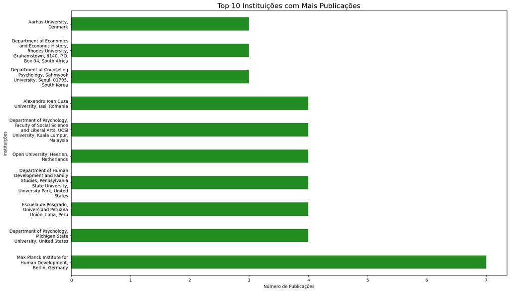

```python
top_instituicoes = instituicoes_contagem.head(10)
plt.figure(figsize=(18, 11))
top_instituicoes.plot(kind='barh', color='forestgreen')
plt.title('Top 10 Instituições com Mais Publicações', fontsize = 16)
plt.xlabel('Número de Publicações')
plt.ylabel('Instituições')

# Ajustar as legendas do eixo y
ax = plt.gca() # Obter o eixo atual
labels = [item.get_text() for item in ax.get_yticklabels()] # Obter as legendas atuais
for i, label in enumerate(labels):
    new_label = textwrap.fill(label, 25)
    labels[i] = new_label
ax.set_yticklabels(labels) # Definir as novas legendas


plt.show()
```

**Evolução temporal do número de publicações das 5 instituições com maior número de publicações**

```python
# Obter as 5 instituições com maior número de publicações
top_5_instituicoes = instituicoes_contagem.head(5).index.tolist()

top_5_instituicoes
```

```
['Max Planck Institute for Human Development, Berlin, Germany',
 'Department of Psychology, Michigan State University, United States',
 'Escuela de Posgrado, Universidad Peruana Unión, Lima, Peru',
 'Department of Human Development and Family Studies, Pennsylvania State University, University Park, United States',
 'Open University, Heerlen, Netherlands']
```

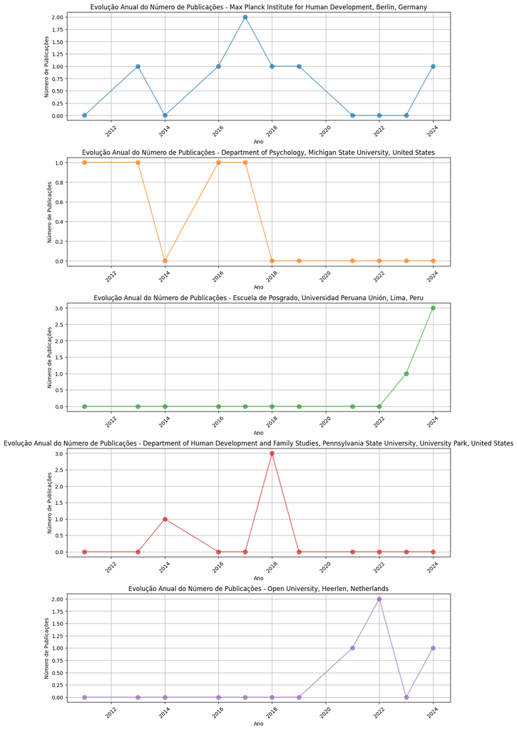

```python
#Expansão da coluna 'Affiliations' para separar as instituições
df_expanded = DataFrame.assign(Affiliations=DataFrame['Affiliations'].str.split(';')).explode('Affiliations')
df_expanded['Affiliations'] = df_expanded['Affiliations'].str.strip()

#Filtrar o DataFrame para as 5 instituições mais publicadas
df_top_5 = df_expanded[df_expanded['Affiliations'].isin(top_5_instituicoes)]

#Contabilizar as publicações por ano e por instituição
pub_counts_by_year = df_top_5.groupby(['Year', 'Affiliations']).size().unstack(fill_value=0)

#Definir uma lista de cores para cada instituição
colors = ['#1f77b4', '#ff7f0e', '#2ca02c', '#d62728', '#9467bd']  # Cores distintas para cada gráfico

#Criar subplots para cada instituição (5 subgráficos dispostos verticalmente)
fig, axes = plt.subplots(nrows=5, ncols=1, figsize=(12, 20))  # 5 linhas e 1 coluna
fig.tight_layout(pad=5.0)  # Ajusta o layout para evitar sobreposição

#Plotar cada gráfico em um subgráfico com cores diferentes
for i, institution in enumerate(top_5_instituicoes):
    axes[i].plot(pub_counts_by_year.index, pub_counts_by_year[institution], label=institution,
                 marker='o', markersize=8, alpha=0.7, color=colors[i])  # Usando cores da lista
    axes[i].set_title(f'Evolução Anual do Número de Publicações - {institution}')
    axes[i].set_xlabel('Ano')
    axes[i].set_ylabel('Número de Publicações')
    axes[i].grid(True)
    axes[i].tick_params(axis='x', rotation=45)  # Rotaciona os anos no eixo x para melhor leitura

plt.show()
```

## **4. Onde?**

**Distribuição geográfica da pesquisa**

No que se refere a este tópico, foi gerado um mapa de coautoria utilizando o VOSviewer, que permitem identificar de forma clara os principais padrões de colaboração científica e a influência dos países mais relevantes na investigação sobre os determinantes da felicidade e do bem-estar emocional. Entre os dez países mais influentes, destacam-se os Estados Unidos, Reino Unido, China, Alemanha, Espanha, Austrália, Países Baixos, Coreia do Sul, Turquia e Itália. Cada um destes países tem contribuído significativamente para a produção científica nesta área, sendo a sua relevância moldada por fatores como o volume de documentos publicados, a força das colaborações internacionais e o impacto das publicações, medido pelo número de citações.

```python
# URL do VOSviewer
url = "https://tinyurl.com/28jkwtn9"

display(Markdown("## Mapa da Distribuição Geográfica da Pesquisa"))
# Criar o IFrame
iframe_autKeywords = IFrame(src=url, width="100%", height="600px", style="border: 1px solid #ddd; max-width: 1000px; min-height: 500px")

# Exibir o IFrame
display(iframe_autKeywords)
```

Mapa da Distribuição Geográfica da Pesquisa

[interactive chart not shown]

**Tabela: Distribuição geográfica da pesquisa**

```python
countries_df = dataframes['countries']

# Criar um novo DataFrame com as colunas desejadas
tabela_countries = countries_df[['label', 'cluster','weight<Links>',
       'weight<Total link strength>','weight<Documents>', 'weight<Citations>',
       'weight<Norm. citations>']].copy()

# Remove os missing values
tabela_countries= tabela_countries.dropna(how='all').reset_index(drop=True)

# Renomear as colunas para português
tabela_countries.columns = ['Países', 'Cluster','Força das Ligações',
                         'Força Total das Ligações','Número de Documentos','Número de Citações', 'Citações Normalizadas']

tabela_countries_ordenada = tabela_countries.sort_values(by=['Número de Citações'], ascending=False)
tabela_countries_ordenada['Países'] = tabela_countries_ordenada['Países'].apply(lambda x: x.title())

# Para exibir como tabela interativa no Colab:
data_table.DataTable(tabela_countries_ordenada)
```

|  | Países | Cluster | Força das Ligações | Força Total das Ligações | Número de Documentos | Número de Citações | Citações Normalizadas |
| --- | --- | --- | --- | --- | --- | --- | --- |
| 0 | United States | 5 | 51 | 277 | 449 | 14123 | 518.9281 |
| 1 | United Kingdom | 3 | 55 | 253 | 258 | 8368 | 341.3888 |
| 5 | Australia | 5 | 41 | 126 | 103 | 3902 | 213.0972 |
| 3 | Germany | 4 | 42 | 155 | 136 | 3777 | 154.5577 |
| 6 | Netherlands | 1 | 37 | 123 | 102 | 3192 | 155.0173 |
| ... | ... | ... | ... | ... | ... | ... | ... |
| 57 | Kazakhstan | 1 | 10 | 11 | 9 | 41 | 5.5263 |
| 54 | Jordan | 5 | 10 | 11 | 11 | 38 | 10.7613 |
| 58 | Nigeria | 3 | 4 | 6 | 9 | 27 | 2.8748 |
| 62 | Latvia | 1 | 5 | 6 | 7 | 24 | 0.8403 |
| 55 | Ukraine | 1 | 3 | 3 | 10 | 20 | 12.0632 |

67 rows × 7 columns

**ANÁLISE DOS TOP 10 PAÍSES QUE MAIS SE DESTACAM**

No cluster 3, o Reino Unido sobressai com 258 documentos, uma força total de ligações de 253 e impacto global significativo (8368 citações e 341.39 em citações normalizadas), atuando como elo entre a Europa, os EUA e a Austrália. A China, com 164 documentos e uma força total de ligações de 117, tem uma influência regional crescente (2503 citações), mas ainda menor em escala global.

O cluster 4 destaca a Alemanha e a Itália. A Alemanha, com 136 documentos e uma força total de ligações de 155, lidera na Europa com colaborações robustas e impacto relevante (3777 citações). A Itália, com 87 documentos, 1481 citações e uma força total de ligações de 120, apresenta uma contribuição mais modesta, mas significativa.

No cluster 1, a Holanda, com 102 documentos, 3192 citações e uma força total de ligações de 123, posiciona-se como um país relevante na Europa e em colaborações internacionais. A Turquia, com 92 documentos e 699 citações, emerge como um ator regional, embora com um impacto relativamente menor (força total de ligações: 74).

Por fim, no cluster 6, a Espanha, com 122 documentos e uma força total de ligações de 124, mantém uma rede colaborativa diversificada, incluindo parcerias na Europa e América Latina. Com 1701 citações, apresenta uma contribuição sólida, ainda que moderada, ao cenário científico.

## **Desafio: Como é que as técnicas de Machine Learning poderiam ter uma aplicação útil no contexto das publicações científicas ?**

Cada vez mais, as técnicas de *Machine Learning* têm vindo a ser utilizadas, nas mais diversas áreas do conhecimento, por proporcionarem diferentes benefícios, especialmente perante um grande volume de dados. Atendendo a isso, é de considerar que, efetivamente, a aplicação de modelos no contexto desta investigação, pode oferecer *insights* valiosos e novas perspectivas sobre os fatores que contribuem para o bem-estar emocional. Deste modo, algumas das técnicas de *machine learning* que se mostram adequadas incluem a clusterização, a redução de dimensionalidade e a classificação.

Nesta fase inicial de análise bibliométrica, as técnicas de *clustering*, particularmente, mostraram-se promissoras, e permitiram agrupar publicações científicas com base em similaridades e identificar padrões ocultos nos dados. Explorada com o auxílio do *software VosViewer*, a técnica de clusterização possibilitou, por exemplo, o agrupamento de palavras com uma relação latente, associada por exemplo ao tipo de fator que representavam.

Já a redução de dimensionalidade, que também é um método de aprendizagem não supervisionada, poderia ser implementada em etapas futuras para simplificar e otimizar a análise de dados de alta dimensionalidade. Por exemplo, a Análise de Componentes Principais (PCA) poderia ser aplicada para identificar combinações das variáveis originais, como as palavras-chave, o ano de publicação, o país de origem, e métricas como por exemplo o fator de impacto da revista, de modo a explicar a maior parte da variância dos dados. Essas combinações formariam um conjunto reduzido de componentes principais que poderiam capturar os aspetos mais importantes das publicações, mantendo apenas as dimensões mais significativas e descartando variáveis redundantes ou menos relevantes. Desta forma, padrões ocultos e agrupamentos entre as publicações deste tema poderiam emergir com mais clareza, possibilitando a identificação de subtemas ou tendências nos estudos sobre a felicidade, como estudos focados em aspetos culturais *versus* psicológicos, ou comparações entre diferentes países ou períodos temporais.

Por fim, a classificação, um método de aprendizagem supervisionada, é outra técnica que poderia ser aplicada em fases subsequentes, desde que sejam disponibilizados dados rotulados. Nesse caso, por exemplo, poderiam utilizar-se indicadores específicos de revistas, como o fator de impacto ou até mesmo o número de citações, para construir um conjunto de dados de treino com revistas previamente classificadas como "boas" ou "relevantes" e "menos relevantes" ou "más". A partir disso, um modelo de classificação, como uma árvore de decisão ou uma rede neural, poderia aprender a identificar automaticamente a qualidade de novas revistas com base nesses indicadores, permitindo uma análise mais direcionada e facilitando a identificação das publicações mais relevantes dentro deste campo científico.

## **Conclusão**

Em suma, com a análise bibliométrica das publicações alvo do estudo, foi possível responder às principais questões que surgem no âmbito da exploração inicial de dados: **O quê?**, **Quem?**, **Onde?** e **Quando?**. Assim, conseguiu-se obter uma visão geral sólida das tendências na área, sendo viável avançar para a próxima parte da investigação, onde se procederá com a análise de conteúdo.

Ao longo deste projeto, ficou clara a magnitude da ciência de dados e das técnicas de *Machine Learning* no estudo de temas complexos no âmbito das ciências sociais, como a felicidade e o bem-estar emocional. Tornou-se evidente como ferramentas de análise como o *VOSviewer* possibilitam a exploração de grandes volumes de dados e a deteção de padrões que seria inconcebível de ser feito manualmente. Somando a isto, o clustering comprovou ser uma técnica deveras valiosa, no que respeita à organização dos dados de forma exploratória de modo a descobrir relações latentes entre os fatores. Desta forma, este estudo não só contribuiu para a compreensão dos determinantes da felicidade, como também reforçou o papel das metodologias de dados em investigações sociais, promovendo uma análise mais ampla e detalhada de questões subjetivas. No entanto, existe uma limitação inerente a esta investigação que não pode ser descartada na interpretação dos resultados. No que respeita à fonte de dados, apesar da *Scopus* ter sido uma escolha fundamentada na sua ampla gama de publicações, nem todas as publicações relevantes podem estar nela disponíveis, o que pode produzir um viés. Assim, este trabalho estabelece um ponto de partida sólido para futuras investigações sobre felicidade e bem-estar, oferecendo uma base metodológica robusta que pode ser ampliada e refinada com a integração de outras fontes de dados e abordagens analíticas.